# Lab 09: Annotating Data Visualizations

## Pick a dataset

Murder rates across different cities in the US:

## Instructions

Your goal in this lab is to construct an interesting visualization with the data that you choose above. You should make use of several manual annotations in an effort to tell a visual story about the dataset. Below, you should eventually provide a few sentences describing what you found in the dataset and then a single plot illustrating the interesting aspects of the data. You should incorporate some external information into your plot.

Note that you will certainly want to create many initial exploratory plots before settling on a final one for analysis. This time, make sure you that you upload both the Rmd and the html files to GitHub (remember, the final report should have just one single visualization).

Also note that you will have to use the format `x = as.Data("2017-01-06")` to add annotations to an axis that uses time as a component.

## Analysis

[figure not shown]

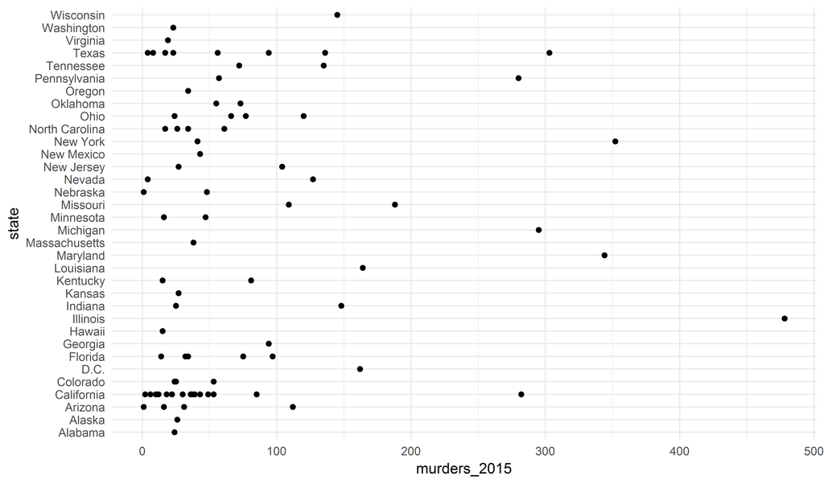

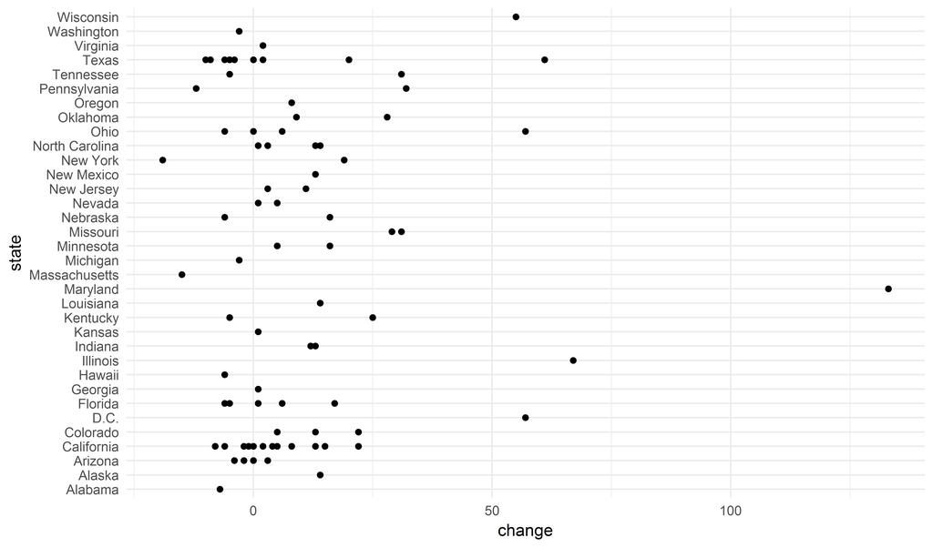